# Workflow using dplyr

Giovanni d’Ario

9/11/2019

```r
### Tidyverse libraries
library(magrittr)
library(tibble)
library(dplyr)
library(tidyr)
```

```r
library(ggplot2)
```

```r
### Parallel processing
library(foreach)
library(doParallel)
### rstan and utilities
library(rstan)
rstan_options(auto_write = TRUE)
util <- new.env()
```

We simulate 1000 draws from the 100 detectors.

```r
R <- 1000 # 1000 draws from the Bayesian joint distribution
N <- 100

simu_data <- list("N" = N)

fit <- stan(file = 'sample_joint_ensemble.stan', data = simu_data,
            iter = R, warmup = 0, chains = 1, refresh = R,
            seed = 4838282, algorithm = "Fixed_param")
```

The `fit` object contains the simulated `lambda`s and `y`s.

```r
simu_params <- extract(fit)
simu_lambdas <- simu_params$lambda
simu_ys <- simu_params$y
```

We can visualize the distribution of the values of `lambda` in a histogram.

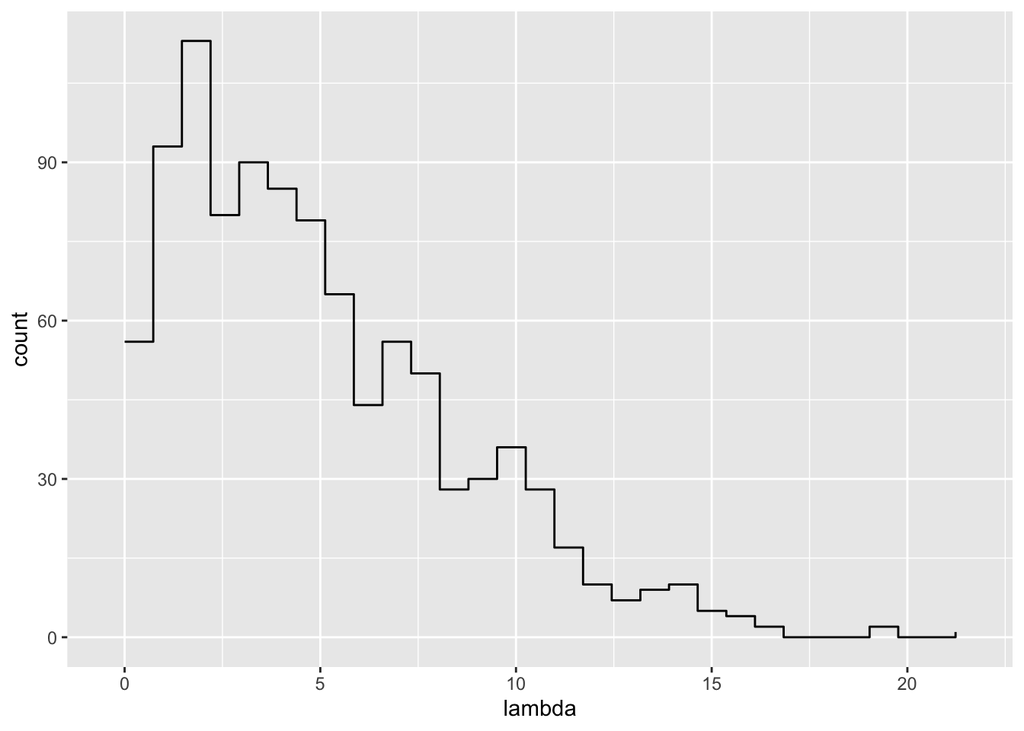

```r
df_simu_ys <- data.frame(simu_ys)
colnames(df_simu_ys) <- paste0("D", 1:100)
df_simu_ys$lambda <- simu_lambdas

ggplot(df_simu_ys, aes(x = lambda)) + stat_bin(geom = "step")
```

We can visualize the histograms for the first 10 runs as follows:

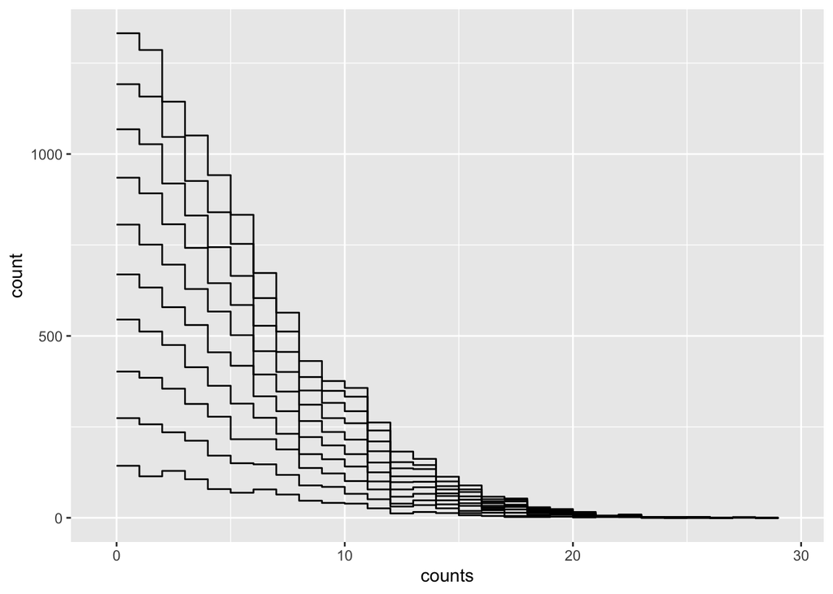

```r
tmp <- df_simu_ys[, 1:10] %>%
  gather(key = "run", value = "counts")
ggplot(tmp, aes(x = counts, group = run)) + stat_bin(geom = "step")
```

Or we can visualize them all:

```r
tmp <- df_simu_ys %>% gather(key = "run", value = "counts")
```

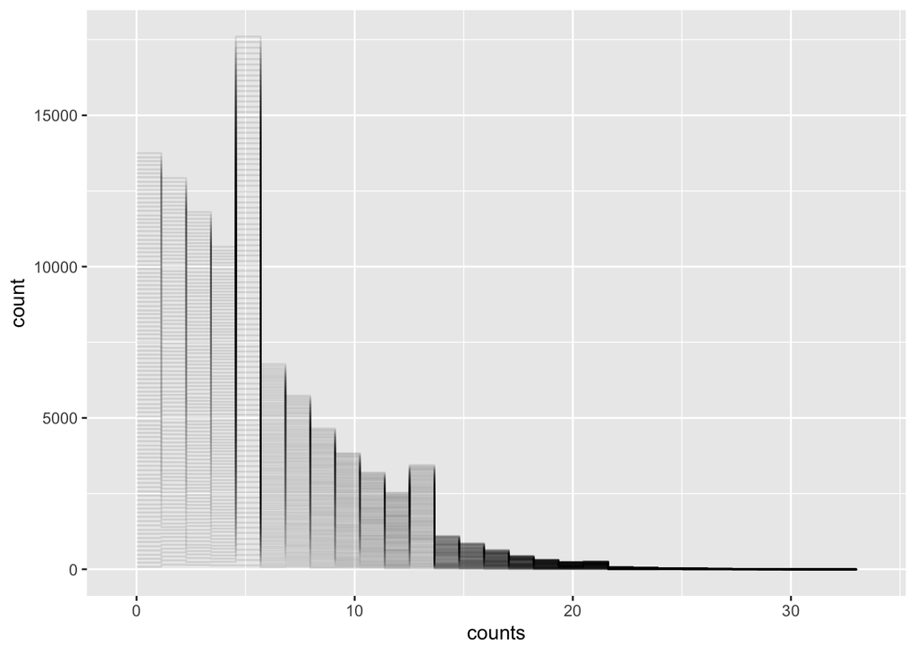

```r
ggplot(tmp, aes(x = counts, group = run)) + stat_bin(geom = "step", alpha=0.1)
```

This visualization, however, doesn’t make things clearer. We can first bin the counts on each row, and then compute the quantiles for these counts.

```r
bin_and_count <- function(x, B=40, br=0:(B + 1) - 0.5) {
  hist(x, breaks = br, plot = FALSE)$counts
}

bin_counts <- apply(simu_ys, 1, bin_and_count)
```

We can then compute the quantiles of each bin across the 1000 runs. The black line represent the median.

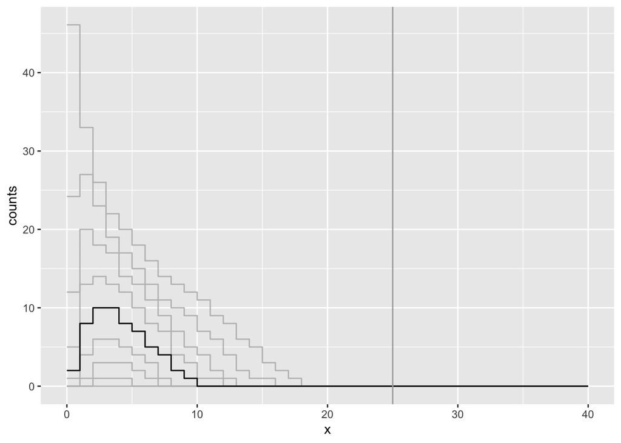

```r
pbs <- c(0.1, 0.2, 0.3, 0.4, 0.5, 0.6, 0.7, 0.8, 0.9)
quants <- apply(bin_counts, 1, quantile, probs = pbs)

df_quants <- as_tibble(t(quants))
df_quants$x <- 0:40

## Create a data frame with the quantiles of each bin.
df_quants %<>% gather(-x, key = "quantile", value = counts)

## Plot the quantiles of each bin.
ggplot(df_quants, aes(x = x, y = counts, group = quantile)) +
  geom_step(col = 'grey') +
  geom_step(data = dplyr::filter(df_quants, quantile == "50%"), col = "black") +
  geom_vline(xintercept = 25, color = "darkgrey")
```

## Evaluate the simulated files

```r
compute_metrics <- function(simu,
                            N=N,
                            model,
                            thin=8,
                            prior_sd_lambda=5.82337,
                            seed=4938483) {
  simu_lambda <- simu[1]
  simu_y <- simu[-1]

  input_data <- list("N" = N, "y" = simu_y)

  capture.output(
    fit <- sampling(model, data = input_data, seed = seed)
  )

  ## Check if there are problematic cases
  util <- new.env()
  source("stan_utility.R", local = util)
  warning_code <- util$check_all_diagnostics(fit, quiet = TRUE)

  ## Simulation Based Calibration ranking
  lambda <- extract(fit)$lambda
  sbc_rank <- sum(simu_lambda < lambda[seq(1, length(lambda) - thin, thin)])

  ## Compute posterior sensitivities
  s <- summary(fit, probs = c(), pars = "lambda")$summary
  post_mean_lambda <- s[, 1]
  post_sd_lambda <- s[, 3]

  z_score <- (post_mean_lambda - simu_lambda) / post_sd_lambda
  shrinkage <- 1 - (post_sd_lambda / prior_sd_lambda)**2

  c(warning_code, sbc_rank, z_score, shrinkage)
}
```

We can run the above function in parallel on all the available cores.

```r
tryCatch({
  ## Register doParallel
  registerDoParallel(cores = detectCores())

  ## Create a data frame of simulated lambdas and ys
  ## data.matrix converts a data frame into a matrix
  simu_list <- t(data.matrix(data.frame(simu_lambdas, simu_ys)))

  ## Fit the model that computes the posterior density (we need to do it once).
  fit_model = stan_model(file='fit_data.stan')

  ensemble_output <- foreach(simu = simu_list, .combine = "cbind") %dopar% {
    compute_metrics(simu, N, fit_model)
  }
}, finally = {stopImplicitCluster()})
```

The result is a 4 x 1000 matrix with, in order, the number of warnings, the rank the z score, and the shrinkage.

```r
print(dim(ensemble_output))
```

```
## [1]    4 1000
```

```r
rownames(ensemble_output) <- c("num_warnings", "sbc_rank", "z_score", "shrinkage")
output_df <- data.frame(t(ensemble_output))
```

We can first check whether we have any warning message.

```r
sum(ensemble_output[1, ])
```

```
## [1] 0
```

We have zero warnings. This is good. We can then plot a histogram of the SBC ranks.

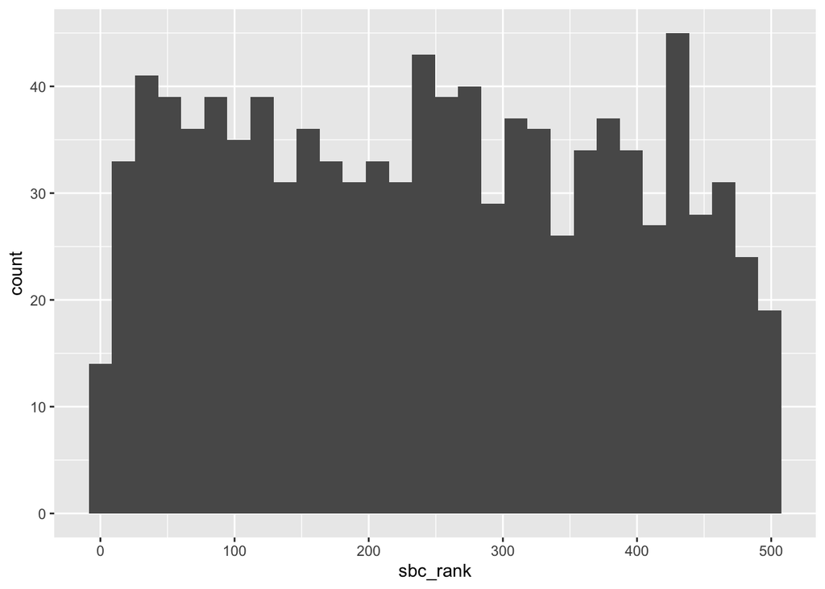

```r
ggplot(output_df, aes(sbc_rank)) + geom_histogram()
```

Uhm… I wouldn’t bet that this reflects a uniform distribution. Can we recreate the plot in the use case?

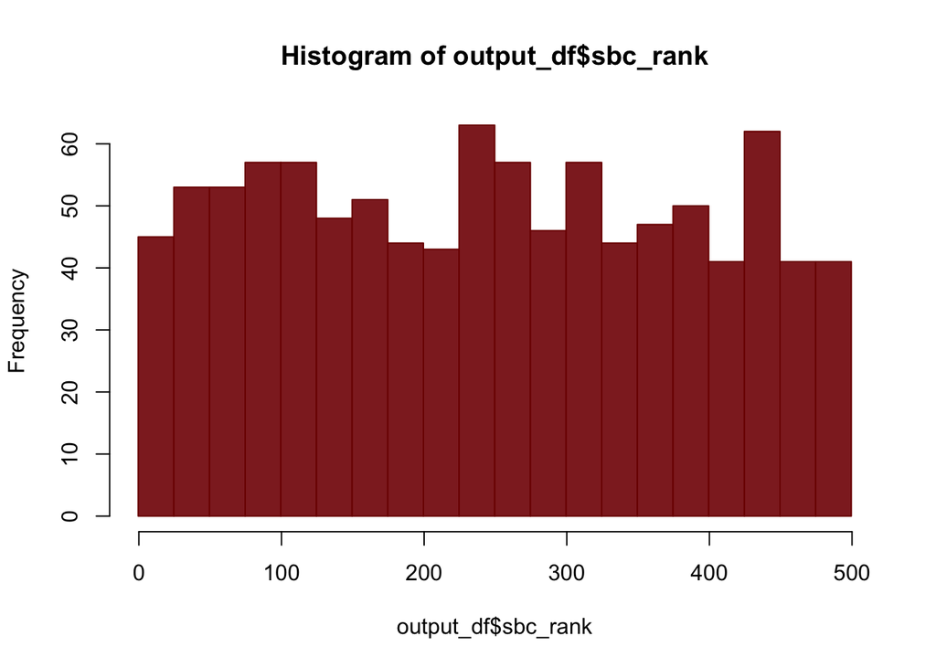

```r
### Define the colors
c_light <- c("#DCBCBC")
c_light_highlight <- c("#C79999")
c_mid <- c("#B97C7C")
c_mid_highlight <- c("#A25050")
c_dark <- c("#8F2727")
c_dark_highlight <- c("#7C0000")

sbc_hist <- graphics::hist(output_df$sbc_rank,
                           seq(0, 500, 25) - 0.5,
                           col = c_dark,
                           border = c_dark_highlight)
```

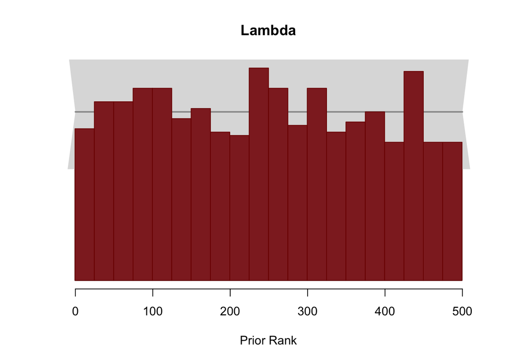

```r
plot(sbc_hist, main = "Lambda", xlab = "Prior Rank", yaxt = 'n', ylab = "")

low <- qbinom(0.005, R, 1 / 20)
mid <- qbinom(0.5, R, 1 / 20)
high <- qbinom(0.995, R, 1 / 20)
bar_x <- c(-10, 510, 500, 510,-10, 0,-10)
bar_y <- c(high, high, mid, low, low, mid, high)

polygon(bar_x, bar_y, col = c("#DDDDDD"), border = NA)
segments(x0 = 0, x1 = 500, y0 = mid, y1 = mid, col = c("#999999"), lwd = 2)

plot(sbc_hist, col = c_dark, border = c_dark_highlight, add = TRUE)
```

## Z scores and posterior shrinkage

We can plot the `z_score` vs the `shrinkage` and see where our simulations fall.

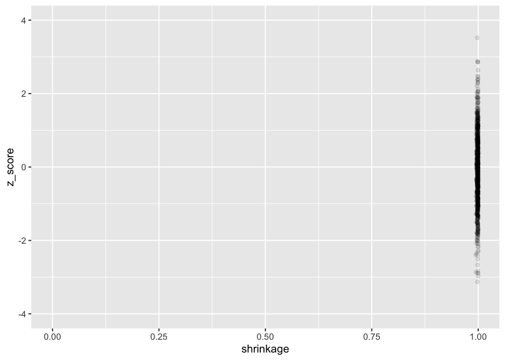

```r
ggplot(output_df, aes(x = shrinkage, y = z_score)) +
  geom_point(alpha = .1) +
  xlim(0, 1) + ylim(-4, 4)
```